# Lab 9 - Correlation & Regression

Carter Allen

11/28/2018

## Intoduction

So far in this class, we have covered methods for testing relationships between (i) two categorical variables (think back to the contingency tables material) and between (ii) a categorical variable and a continuous variable (either t-tests or ANOVA). The next natural progression will be to look at ways of measuring relationships between two continuous variables.

## Visualizing Two Continuous Variables

A scatterplot is generally the most appropriate plot for displaying the relationship between two continuous variables. For two continuous numeric random variables $X$ and $Y$, a scatterplot displays a point on the coordinate plane for each $(X,Y)$ pair.

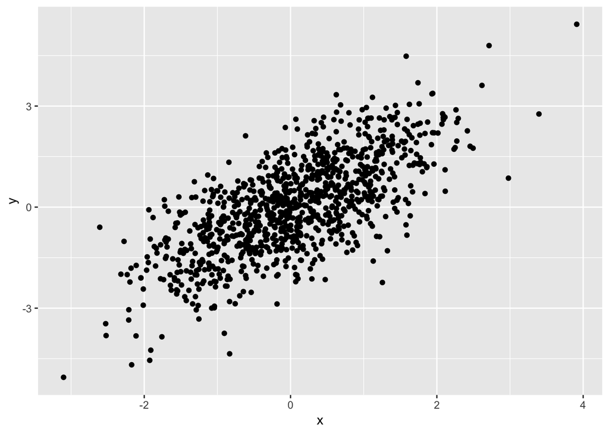

Scatterplot of two continuous variables.

In many research settings, we designate one variable to be the *outcome* and one variable to be the *predictor*. The implication here is that changing the predictor variable will result is some corresponding change in the outcome variable. However, we do not assume the reverse is true. That is, we are not interested in observing how changing the outcome variable causes a change in the predictor variable. In fact, usually the outcome variable is observable but not controllable in most experimental settings, while the predictor variable can be manipulated by the experimenter. It is also the case often that neither the predictor variable nor the outcome variable are controllable by experimentation. In this case, we are making observations on both variables and checking how one variable tends to change as another changes. As a convention, we place the outcome on the vertical axis and the predictor variable on the horizontal axis.

## Measuring Association

A plot helps us vizualize how one variable changes *along with* another variable, but how can we measure how associated two variables are?